# Teona_final project

Teona

2024-11-15

#Load the appropriate software libraries

```r
library(tidyverse)
library(pdftools)
```

#Load the data

```r
text <- pdf_text("moley_final.PDF")

writeLines(text, "moley_final.txt")
```

```r
file_path <- "moley_final.txt"
text_data <- readLines(file_path)
text_combined <- paste(text_data, collapse = "\n")
documents <- strsplit(text_combined, "End of Document")[[1]]

output_dir <- "./extracted"
dir.create(output_dir, showWarnings = FALSE)

for (i in seq_along(documents)) {
  output_file <- file.path(output_dir, paste0("moley_extracted", i, ".txt"))
  writeLines(documents[[i]], output_file)
}
cat("Files created:", length(documents), "\n")
```

```
## Files created: 33
```

#Spell out your content analysis plan, including preliminary work on a code book

#1: Content analysis plan:

I plan to explore how ideas and themes have evolved in Moley’s narratives overtime. I will use R to identify frequent terms and specific keywords. I also plan to apply sentiment analysis to classify tone. I will use ggplot to visualize the trends in sentiments for overtime.

#2: Preliminary work on a codebook:

(My codebook planning is based on the reading from Week 5: Sept. 24, 2024 readings)

Economic Policy: The articles communicate Moley’s ideas about economic policy’s. I will track the frequency and context of using key words, such as “new deal” and “reform”.

Ideological Stances: Tracking down Moley’s and his his circle’s ideological stances (“liberalism” and “conservatism”) and how these positions evolved thruought the years and noting if any significant changes happened.

Character Names and Descriptions: The articles mention of some of the key names of the state actors. I will gather full names and brief descriptions of their roles and relationships with Moley.

Character ID: Give each character a unique 4-digit number, beginning with 0001. If a character appears in more than one episode, code him or her each time, but use the same ID number.

Eppetites about Moley: Moley became known as “the second strongest man in Washington”. They would also refer him as “Columbia university professor”, “Roosevelt’s brain trust”. I will explore how the adjectives related to Moley have been changing over the years.

```r
library(tidyverse)
library(pdftools)
library(tidytext)


text <- pdf_text("moley_final.PDF")


moley_data <- data.frame(
  page = seq_along(text),
  text = text,
  stringsAsFactors = FALSE
)

write_csv(moley_data, "moley_final.csv")
```

#Provide a sample of the data and some descriptive statistics

```r
library(tidyverse)
library(tidytext)


text_stats <- moley_data %>%
  summarise(
    total_pages = n(),
    total_characters = sum(nchar(text)),
    avg_characters_per_page = mean(nchar(text))
  )

key_terms <- moley_data %>%
  summarise(
    new_deal_mentions = sum(str_count(tolower(text), "new deal")),
    reform_mentions = sum(str_count(tolower(text), "reform")),
    liberalism_mentions = sum(str_count(tolower(text), "liberalism")),
    conservatism_mentions = sum(str_count(tolower(text), "conservatism"))
  )

cat("\nKey Term Frequencies:\n")
```

```
##
## Key Term Frequencies:
```

```r
print(key_terms)
```

```
##   new_deal_mentions reform_mentions liberalism_mentions conservatism_mentions
## 1               288              39                   2                     2
```

```r
doc_lengths <- moley_data %>%
  mutate(
    word_count = str_count(text, "\\w+")
  ) %>%
  summarise(
    min_words = min(word_count),
    max_words = max(word_count),
    mean_words = mean(word_count),
    median_words = median(word_count),
    sd_words = sd(word_count)
  )

cat("\nDocument Length Statistics:\n")
```

```
##
## Document Length Statistics:
```

```r
print(doc_lengths)
```

```
##   min_words max_words mean_words median_words sd_words
## 1        16      1056   509.6047          517 277.6628
```

#Using code, describe the number of rows and columns of the dataset

```r
documents <- strsplit(text_combined, "End of Document")[[1]]
```

```r
length(documents)
```

```
## [1] 33
```

```r
documents_df <- data.frame(documents = documents)
nrow(documents_df)
```

```
## [1] 33
```

```r
ncol(documents_df)
```

```
## [1] 1
```

#Create ggplot chart showing the distribution of the data over time

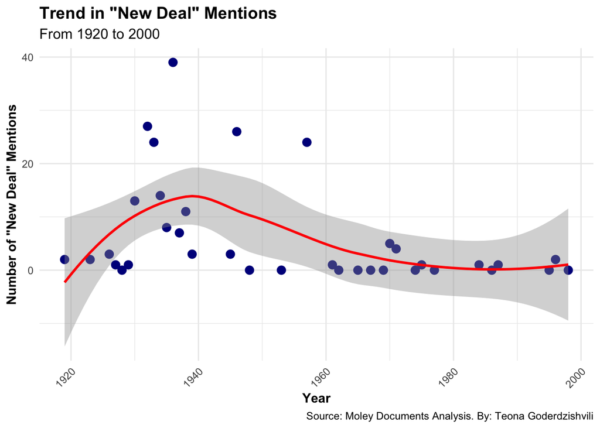

```r
library(tidyverse)
library(tidytext)

new_deal_mentions <- moley_data %>%
  mutate(year = str_extract(text, "19[0-9]{2}")) %>%
  filter(!is.na(year)) %>%
  mutate(
    year = as.numeric(year),
    new_deal_count = str_count(tolower(text), "new deal")
  ) %>%
  group_by(year) %>%
  summarize(frequency = sum(new_deal_count))


ggplot(new_deal_mentions, aes(x = year, y = frequency)) +
  geom_point(color = "darkblue", size = 3) +
  geom_smooth(method = "loess", color = "red", se = TRUE) +
  theme_minimal() +
  labs(
    title = 'Trend in "New Deal" Mentions',
    subtitle = "From 1920 to 2000",
    x = "Year",
    y = 'Number of "New Deal" Mentions',
    caption = "Source: Moley Documents Analysis. By: Teona Goderdzishvili"
  ) +
  theme(
    plot.title = element_text(face = "bold", size = 14),
    plot.subtitle = element_text(size = 12),
    axis.title = element_text(face = "bold"),
    axis.text.x = element_text(angle = 45, hjust = 1)
  )
```

#Render into an HTML page and post this to the web